# Final Report Analysis: Program Directors

Survey analysis output for cohorts 1 and 2 combined

Published

April 3, 2024

This html displays the key survey results for *N* = 20 program directors and staff. The table of contents on the left can be used to navigate across descriptive statistics categories.

## Culturally Responsive Program Areas

- In which of the following areas does the program at the [organization] offer employees or clients a culturally responsive treatment environment?
  - Organizational values
  - Governance
  - Client treatment planning
  - Evaluation and monitoring
  - Language service
  - Workforce and staff development
  - Organizational infrastructure
  - Other

```
# A tibble: 7 × 3
  Item                  Count Program_Areas
  <chr>                 <int> <chr>
1 cultural_responsive_1    18 Organizational values
2 cultural_responsive_2    10 Governance
3 cultural_responsive_3    16 Client treatment planning
4 cultural_responsive_4    17 Evaluation and monitoring
5 cultural_responsive_5     8 Language service
6 cultural_responsive_6    18 Workforce and staff development
7 cultural_responsive_7    15 Organizational infrastructure
```

## Certification Requirement for Recovery Coaches

Our organization requires that recovery coaches are certified by the state of [org. state].

- Yes/No/Other

```
  prc_certify n proportion CertificationRequired
1           1 9       0.45                   Yes
2           2 7       0.35                    No
3           3 2       0.10                 Other
4        <NA> 2       0.10          Missing Data
```

## Frequency of Recovery Coach’s Contact with Individuals with SUDs

According to program directors, about the majority (90%) of recovery coaches interact with individuals with SUDs at least once/week.

```
  prc_interact  n proportion RC_Interaction_with_SUDs
1            1 15       0.75                    Daily
2            2  3       0.15               1+day/week
3            3  1       0.05            1-2days/month
4           NA  1       0.05             Missing Data
```

## Program Experience

- Program directors responded on a 5-point likert scale (Strongly disagree to strongly agree) for the following experiences with their programs:
- My program has the organizational capacity needed to provide services
- My program is able to leverage grant (i.e., financial) support
- My program is able to collaborate with partners, organizations, and community resources
- My program has received the support needed from AmeriCorps
- The criminal history background check is problematic
- The volunteer stipend is sufficient

The following graph summarizes the responses for each program experience.

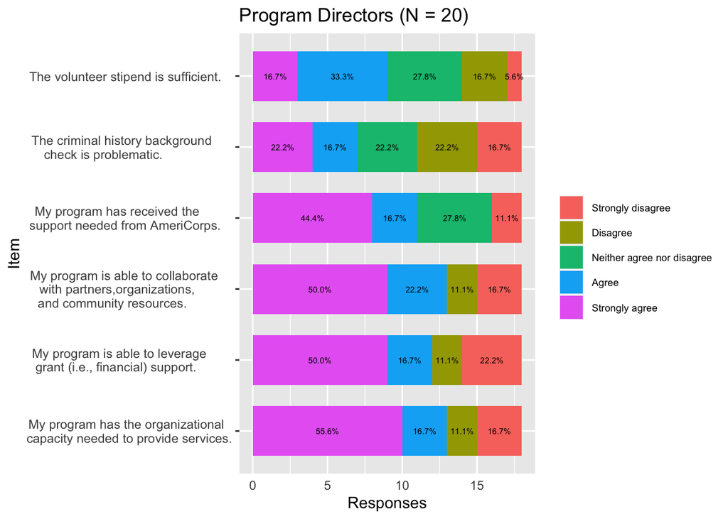

## Federal Opioid Development grant

**Has your organization received funding or resources through the Federal Opioid Development grant?**

```
  FOD_grant  n proportion FOD_grant_supported
1         1  8        0.4                 Yes
2         2 10        0.5                  No
3        NA  2        0.1        Missing Data
```

## Monitoring and Oversight Plan

**Does your program have a monitoring and oversight plan?**

```
  monitoring_plan  n proportion MonitoringPlan
1               1 17       0.85            Yes
2               2  1       0.05             No
3              NA  2       0.10   Missing Data
```

## Recovery Coach Recruitment

- Program directors reported on the methods they used for recruiting recovery coaches:
- Internal recovery program/ program graduates
- Community recovery programs
- Other community organizations
- Schools and universities
- Other

The following graph shows that alumn of **internal programs (N = 13)** are the most commonly reported source of recruited recovery coaches, while **schools and universities (N = 4)** are least commonly reported.

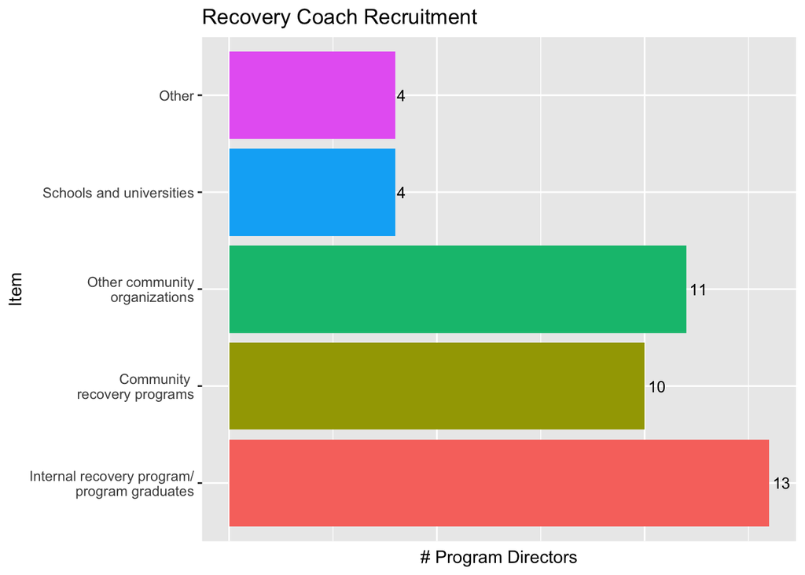

## Lived Experience for Coaches

```
  prc_livedexper  n proportion  LivedExperience
1              1 18       0.90   Very Important
2              5  1       0.05 Very Unimportant
3             NA  1       0.05     Missing Data
```

## Training Format:

**How is the training for Recovery Coaches offered?**

Directors reported on mode of training delivery for coaches.

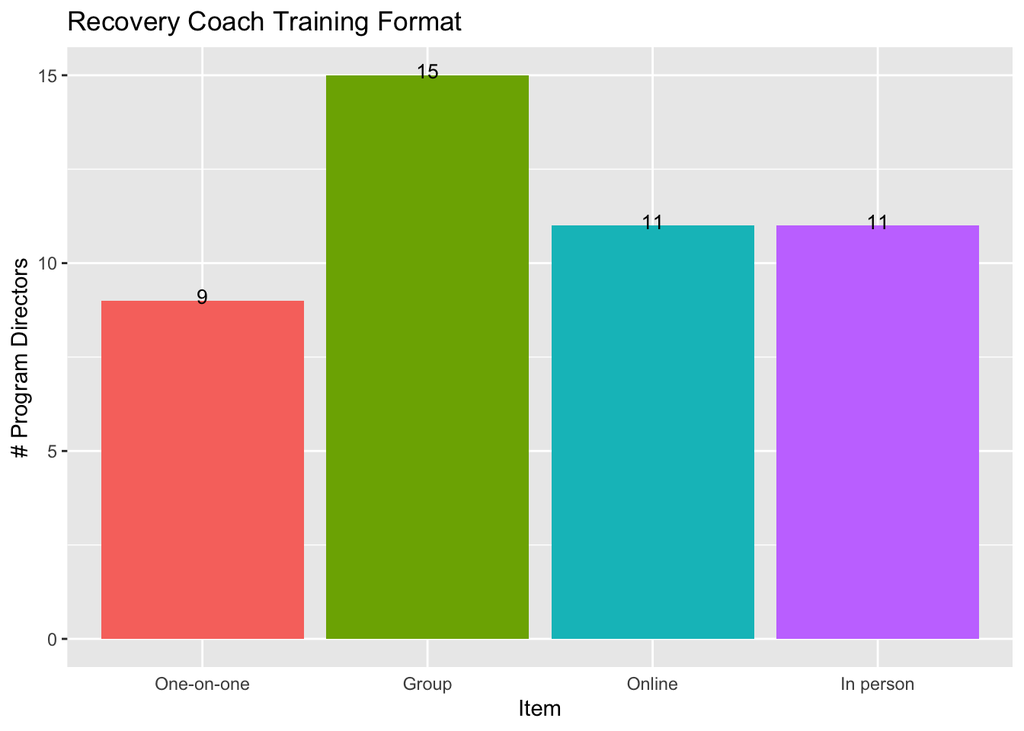

## Supports:

**What other supports or services do you connect clients to?** + Food assistance + Transportation assistance + Emergency shelter + Physical or behavioral health providers + Other

Program directors commonly reported services/supports for clients, which aligns with what was found in the focus groups.

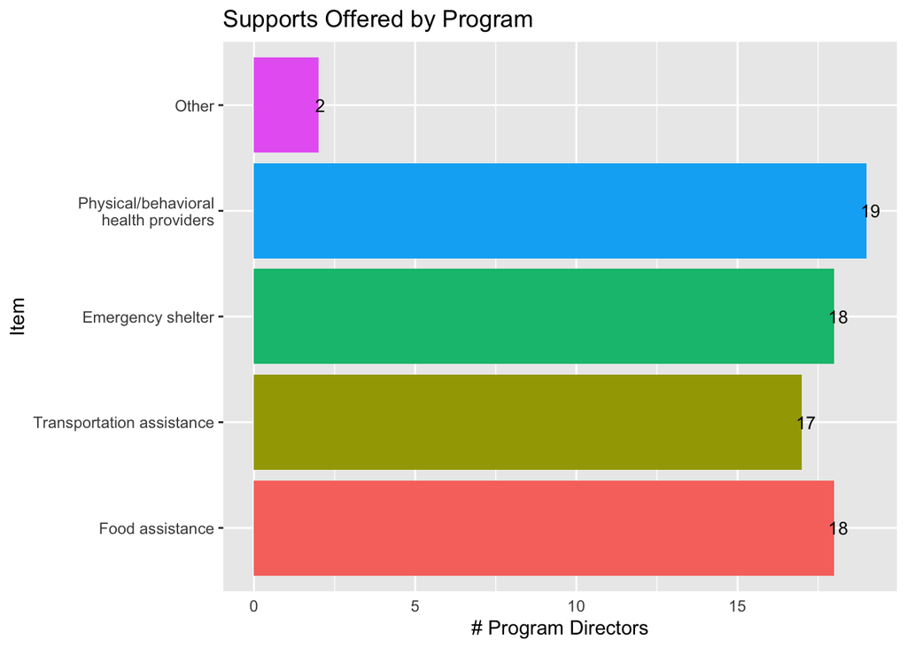

## Treatment services incorporating partipant characteristics

```
# A tibble: 16 × 2
   Item                  Count
   <chr>                 <int>
 1 treatment_services_1     10
 2 treatment_services_10    12
 3 treatment_services_11    10
 4 treatment_services_12    11
 5 treatment_services_13    15
 6 treatment_services_14    17
 7 treatment_services_15    15
 8 treatment_services_16    17
 9 treatment_services_2     15
10 treatment_services_3     17
11 treatment_services_4     15
12 treatment_services_5     12
13 treatment_services_6     11
14 treatment_services_7     16
15 treatment_services_8     17
16 treatment_services_9     17
```

## Onboarding requirments

```
    onboarding  n proportion
1          Yes 18        0.9
2 Missing Data  2        0.1
```

## Track relapse

```
  prc_track_relapses  n proportion track_relapses
1                  1 14       0.70            Yes
2                  2  5       0.25             No
3               <NA>  1       0.05   Missing Data
```

## Recovery coach relapses

```
     prc_relapse  n proportion
1 Very Important 10        0.5
2      Important  2        0.1
3   Missing Data  8        0.4
```

## Maintain contact

```
  maintain_contact  n proportion
1              Yes 18       0.90
2               No  1       0.05
3     Missing Data  1       0.05
```

## Organization support for coaches to connect with one another

**Does your organization provide opportunities for recovery coaches to connect with each other?**

```
   prc_connect  n proportion
1          Yes 18        0.9
2 Missing Data  2        0.1
```